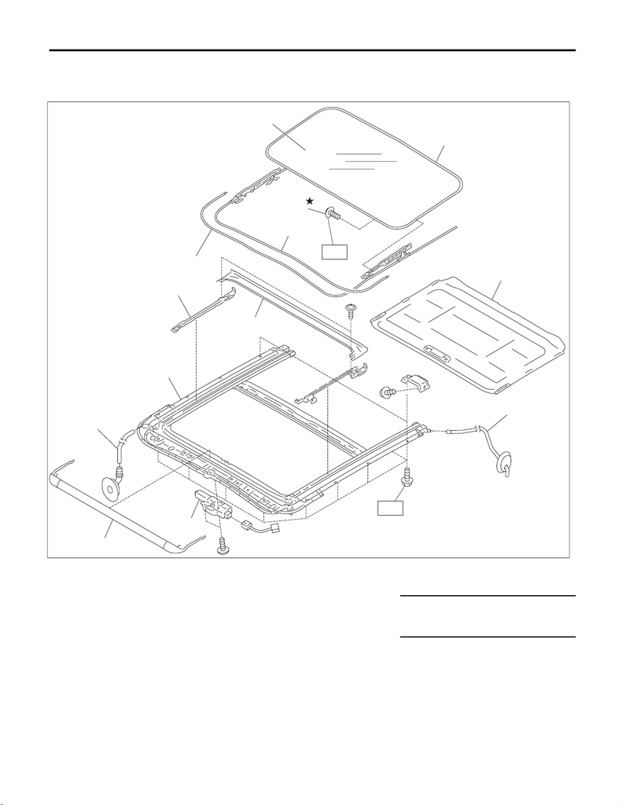

General Description

SUNROOF/T-TOP/CONVERTIBLE TOP (SUNROOF)

1. General Description

A: COMPONENT

B: CAUTION

Before disconnecting connectors of sensors or units, be sure to disconnect the ground cable from battery.

fore disconnecting the battery ground cable.

(1) Lid ASSY - sunroof (6) Deflector ASSY - sunroof (11) TORX

®

bolt

(2) Weather strip (7) Rail ASSY - sunroof

(2)

(3)

(5)

(4)

(4)

(6)

(9)

(10)

(7)

(8)

(10)

T2

T1

(11)

[figure not shown]

General Description

SUNROOF/T-TOP/CONVERTIBLE TOP (SUNROOF)

C: PREPARATION TOOL

1. GENERAL TOOL

TOOL NAME REMARKS

Circuit tester Used for measuring resistance and voltage.

Hexagon wrench Used for forcibly driving the motor assembly - sunroof. Width across flat 4 mm (0.16

in)

TORX

®

T25 Used for removing and installing the lid assembly - sunroof.